# Mixed-model GWAS applied to UKBB

Andrey Ziyatdinov

2019-03-03

# 1 Background

In the majority of genome-wide association studies (GWAS), the marginal genetic effect on a quantitative trait is assessed in a sample of unrelated individuals by using linear regression (LR) models. Performed association tests are computationally fast and have well-known analytical properties: the non-centrality parameter (NCP) of the test is proportional to the sample size ($n$) and the variance explained by genetic variant ($q^2$). However, large population-based cohorts now include a substantial fraction of related individual, and linear mixed models (LMM) have emerged as the standard method in modern association studies. While a notable progress has been recently achieved in efficient implementations of LMM, analytical properties of related association tests are not completely established. Here, we first reviewed and derived the NCP parameter of LMM-based association test for marginal genetic effect. We next extended our derivation for testing gene-environment interaction effect.

We conducted GWAS in simulated data under different scenarios: LR in unrelated individuals, LMM in unrelated individuals, and LMM in related individuals in pedigrees. We confirmed our analytical results that the power of LMM-based test is a function of the sample size ($n$), the variance explained by genetic variant ($q^2$), the relatedness of individuals (the kinship matrix $K$) as well as composition of variance components in LMM, e.g. heritability ($h^2$).

## 1.1 Computing mixed-model GWAS in UK Biobank

When performing GWAS in the UK Biobank study using 336K approximately unrelated individuals and 619,017 high-quality genotyped SNPs with MAF>1%, we sought to *analytically* compare two approaches based on LR and LMM. In the later approach, LMM includes a random genetic effect with a genetic relatedness matrix or GRM, typically constructed from genome-wide SNP data. Previous studies empirically estimated the effective size multiplier that is a quantitative measure of the gain in power when LMM is preferred to LR: taking the average ratio of chi-squared association statistics of genome-wide significant variants computed by BOLT-LMM *vs.* linear regression. In contrast to BOLT-LMM that avoids inverting the GRM matrix in association tests, our analytical solution for the LMM-based NCP requires the expensive operation to compute the inverse of GRM.

# 2 Analytical results

## 2.1 Association tests under the null hypothesis

The genetic effect on phenotype in unrelated individuals is evaluated under the standard linear model $y \sim \mathcal{N} (\mu x_0 + \beta_g x_g, \sigma_r^2 I)$, where $x_0 = 1_n$ is a vector of $n$ ones, $\mu$ is a mean of the phenotypic values, $x_g$ is a vector of length of the genotypic values, $\beta_g$ is the effect size of the genotype. The NCP of association test is well known to be proportional to the sample size and the variance captured by the genotype.

$$\begin{equation}
\tag{1}
NCP_{unrel} \approx \hat{\beta}_g^2 \delta_g^2 n = \hat{\beta}_g^2 2 p (1 - p) n
\end{equation}$$

When individuals are related by genetic or other grouping factors, the following linear mixed model is stated, $y \sim \mathcal{N} (\mu x_0 + \beta_g x_g, \sum_{k=1}^{m}{\sigma_k^2 R_k} + \sigma_r^2 I)$. The initial step in solving such a linear mixed model is to estimate random effects parameters ($\sigma_k^2$ and $\sigma_r^2$) by restricted maximum likelihood (REML) or other optimization technique (Lynch and Walsh 1998). Next, the generalized least squares (GLS) are applied to derive the fixed effects, once the estimate of the variance-covariance matrix is found, $\hat{V} = \sum{\hat{\sigma}_i^2 R_i} + \hat{\sigma}_r^2 I$. The GLS estimate for fixed effects in matrix form is:

$$\hat{\beta} = \left(X^T \hat{V}^{-1} X\right)^{-1} X \hat{V}^{-1} y$$

If the centered genotype is denoted as $\tilde{x}_g$, the estimate of $\beta_g$ and its variance are:

$$\hat{\beta}_g = \left(\tilde{x}_g^T \hat{V}^{-1} \tilde{x}_g\right)^{-1} \tilde{x}_g^T \hat{V}^{-1} \tilde{y}$$

$$var(\hat{\beta_g}) = 1 / (\tilde{x}_g^T \hat{V}^{-1} \tilde{x}_g)$$

We showed (not explained in this document) that the variance of estimate can be further approximated through the term $\tilde{x}_g^T \hat{V}^{-1} \tilde{x}_g$, which is a realization of a quadratic form. The NCP of association test in linear mixed model becomes ($tr$ denotes the trace operator):

$$\begin{equation}
\tag{2}
NCP_{rel} \approx \hat{\beta}_g^2 tr(\hat{V}^{-1} \Sigma_g) = \hat{\beta}_g^2 \delta_g^2 tr(\hat{V}^{-1} K) = \hat{\beta}_g^2 2 p (1 - p) tr(\hat{V}^{-1} K)
\end{equation}$$

### 2.1.1 Association tests under specific scenarios

We further expand the previous equations for two specific cases of (i) related individuals in families; (ii) unrelated individuals analyzed by linear mixed models with a genetic relationship matrix (GRM). We also make use of the connection between the trace operator and eigen-value decomposition.

For individuals in families and the model $y \sim \mathcal{N} (\mu x_0 + \beta_g x_g, \sigma_k^2 K + \sigma_r^2 I)$, we have an updated formula of $NCP_{rel}$.

$$\begin{equation}
\tag{3}
\begin{split}
NCP_{fam} & = \hat{\beta}_g^2 2 p (1 - p) tr \left( \left(\hat{\sigma}_k^2 K + \hat{\sigma}_r^2 I\right)^{-1} K \right) \\
& = \hat{\beta}^2 2 p (1 - p) tr \left( \left(\hat{\sigma}_k^2 I + \hat{\sigma}_r^2 K^{-1}\right)^{-1} \right) \\
& = \hat{\beta}_g^2 2 p (1 - p) \sum_{i=1}^{n}{\left(\hat{\sigma}_k^2 + \hat{\sigma}_r^2 \left(\lambda_{K}^i\right)^{-1}\right)^{-1}}
\end{split}
\end{equation}$$

When modeling a genetic random effect with GRM (denoted as $M$ in equations) in unrelated individuals $y \sim \mathcal{N} (\mu x_0 + \beta_g x_g, \sigma_m^2 M + \sigma_r^2 I)$, we rewrite $NCP_{rel}$ as following.

$$\begin{equation}
\tag{4}
\begin{split}
NCP_{unrel+grm} & = \hat{\beta}_g^2 2 p (1 - p) tr( (\hat{\sigma}_k^2 M + \hat{\sigma}_r^2 I)^{-1} ) \\
& = \hat{\beta}_g^2 2 p (1 - p) \sum_{i=1}^{n}{(\hat{\sigma}_m^2 \lambda_{M}^i + \hat{\sigma}_r^2)^{-1}}
\end{split}
\end{equation}$$

## 2.2 Effective size multiplier under the alternative hypothesis

The effective size multiplier, defined as $NCP_{rel} / NCP_{unrel}$ under the alternative hypothesis, gives a quantitative assessment of gain or loss in power when comparing study designs of related and unrelated individuals. The estimated effect size $\hat{\beta}_g$ is replaced by the true effect size $\beta_g$ in the previous formulas and cancels out when taking the ratio:

$$\begin{equation}
\tag{5}
NCP_{rel} / NCP_{unrel} = tr(\hat{V}^{-1} K) / n
\end{equation}$$
$$\begin{equation}
\tag{6}
NCP_{unrel+grouping} / NCP_{unrel} = tr(\hat{V}^{-1}) / n
\end{equation}$$

# Results / Figures

## Figure 1

Illustration of analytical results given in Equation (5) (blue curves) and (6) (green curves).

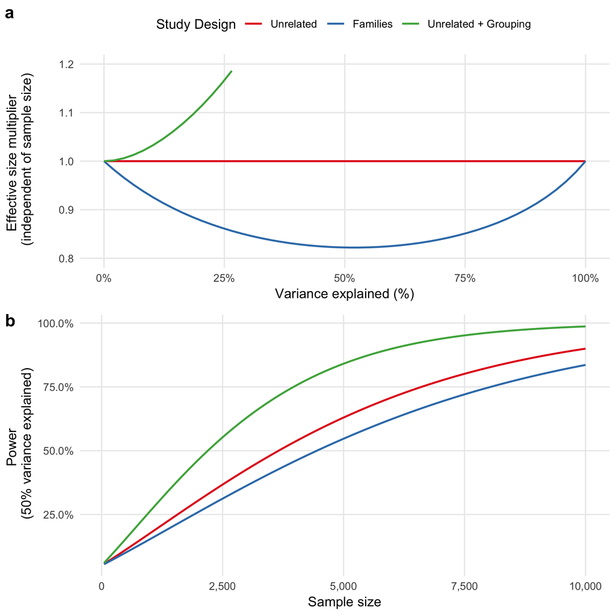

## Figure 2

The effective size multiplier accurately quantifies the comparative GWAS performance of linear regression (LR) and linear mixed models (LMM) regardless mismatches in selecting causal genetic markers for GRM under the LMM model.

A quantitative phenotype in $N$ = 1,000 unrelated individuals is generated from $M_p$ = 200 causal genetic linear predictors, randomly selected from $M$ = 2,000 markers. The variance explained by the causal markers is 80%. Then all $M$ genetic markers were tested for association under LR and under LMM models. Association LMM models are different by the way genetic markers are picked to construct the genetic relationship matrix (GRM): random choice, selection of causal markers (*Oracle*) and selection using top LR association statistics (the number of selected markers varies from 10 to 500).

Note that the standard error of the estimated effect size for a genetic variant is inversely proportional to $\sqrt{N}$ for the LR association model. On the other hand, the same quantity is inversely proportional to $\sqrt{tr(\hat{V}^{-1})}$ for LMM assocation model.

`(i)` The top panel shows that the heritability estimated by LMM approaches the true value 80% (horizontal dotted line), as more causal variants are included in GRM.

`(ii)` The middle panel demonstrates the accuracy of the effective size multiplier (red bars) in predicting the change in the standard errors of effect size estimates between LR and LMM models. Mean and standard deviation of the observed ratios are depicted with dark gray bars and black error bars.

`(iii)` The bottom panel presents a comparison of the observed change in the $\chi^2$ association statistics (squared ratios of Z-scores) with two estimators: the effective size multiplier (red bars) and an estimator from the data generative model (Yang et al. 2014) (blue bars). Observed statistics is collected only for significantly associated variants with P<`1e-5` in the LMM analysis (dark brown bars). Additional variants are filtered out (P>`0.1` in the LR analyses) to excluded variants with low magnitudes estimated effect sizes (light brown bars). See also Figure S1.

The two estimators perform similarly for variants with close estimates of effects sizes obtained by LR and LMM. Though, there is an exception when all $M_p$ = 200 causal markers are selected, including those markers with relatively low effect sizes.

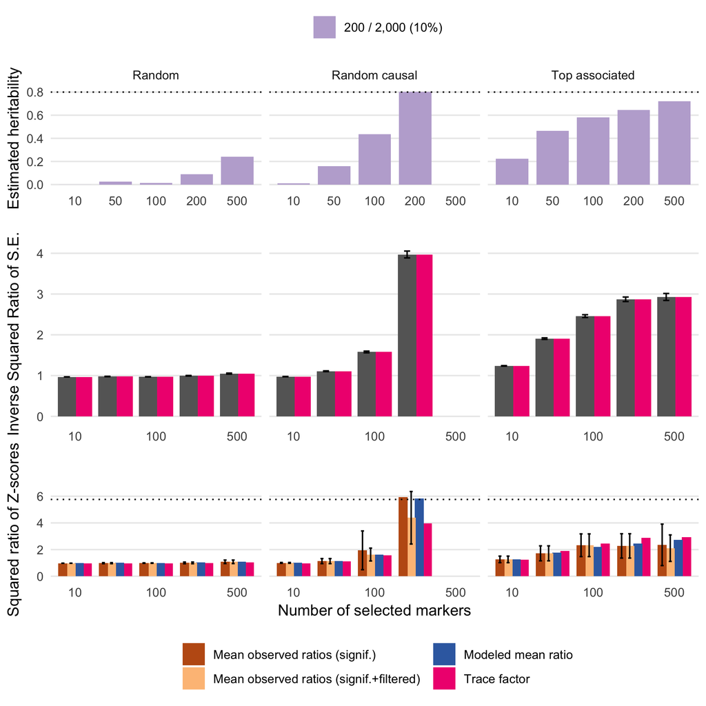

## Figure 3

The effective size multiplier accurately quantifies the comparative GWAS performance of linear regression (LR) and linear mixed models (LMM) on the UK Biobank dataset.

We conduct GWAS on six anthropometric traits and 619,017 high-quality genotyped SNPs with MAF>1% available in a subset of 336,347 unrelated individuals of British ancestry in the UK Biobank dataset, following the data analysis pipeline described in (Loh et al. 2018). We follow a simplified GWAS procedure to speed up the computation.

- The six traits are mean-imputed and relevant covariates are projected out, including center, genotyping array, gender, age, age squared and 20 principal components.
- The LMM association model is based on a low-rank genotype relationship matrix (GRM) constructed using $M_s$ = 1,000 genetic variants with the strongest signals from the LR association analysis (clumping is performed by PLINK) (Young, Wauthier, and Donnelly 2018).
- Only a set of $M_s$ = 1,000 selected genetic variants were assessed in the LMM association analysis and then compared to the LR analysis.

`(i)` The top panel shows the estimated heritability explained by $M_s$ = 1,000 genetic variants for every trait.

`(ii)` The middle panel presents improved precision of effect size estimates by LMM over LR through the observed ratios of standard errors averages across $M_s$ = 1,000 genetic variants (dark gray bars of means and black error bars of standard deviations). The effective size multiplier precisely approximates the observed ratios (red bars).

`(iii)` The bottom panel depict the observed change in the $\chi^2$ association statistics (squared ratios of Z-scores) for all selected genetic variants (dark gray bars) and for those significant selected variants with P<`5e-8` in the LMM analysis (dark brown bars). The effective size multiplier predicts the change in the association statistic reasonably well, although it has a consistent upward bias (red bars). Results by the other estimator (Yang et al. 2014) used for simulated data with 80% heritability are not shown (estimates are far from the observed ratios).

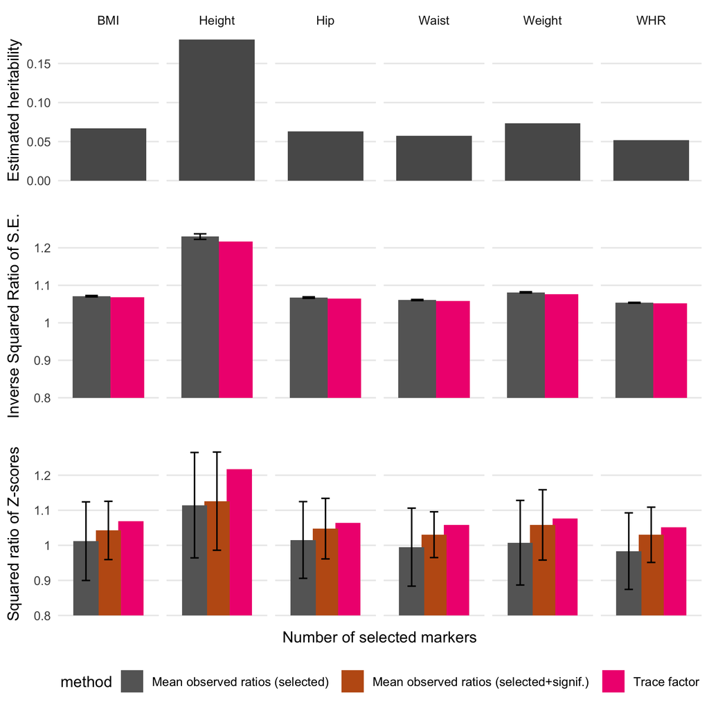

# Supplementary Figures

## Figure S1

Dispersion of the $\chi^2$ association statistics (squared ratios of Z-scores between GWAS analyses based on LR and LMM) for different groups of variants stratified by the effect size magnitudes.

The observed association test statistics for LR and LMM analyses are taken from the simulated data on Figure 2 (middle column, $M_p$ = 200) when all causal markers are selected.

The lower the magnitude of the effect size the larger the dispersion in statistics. When the effect size is close to zero, the *multiplicative* difference for two point estimates of effect sizes for LR and LMM can be rather large, although the absolute error of estimates are fixed.

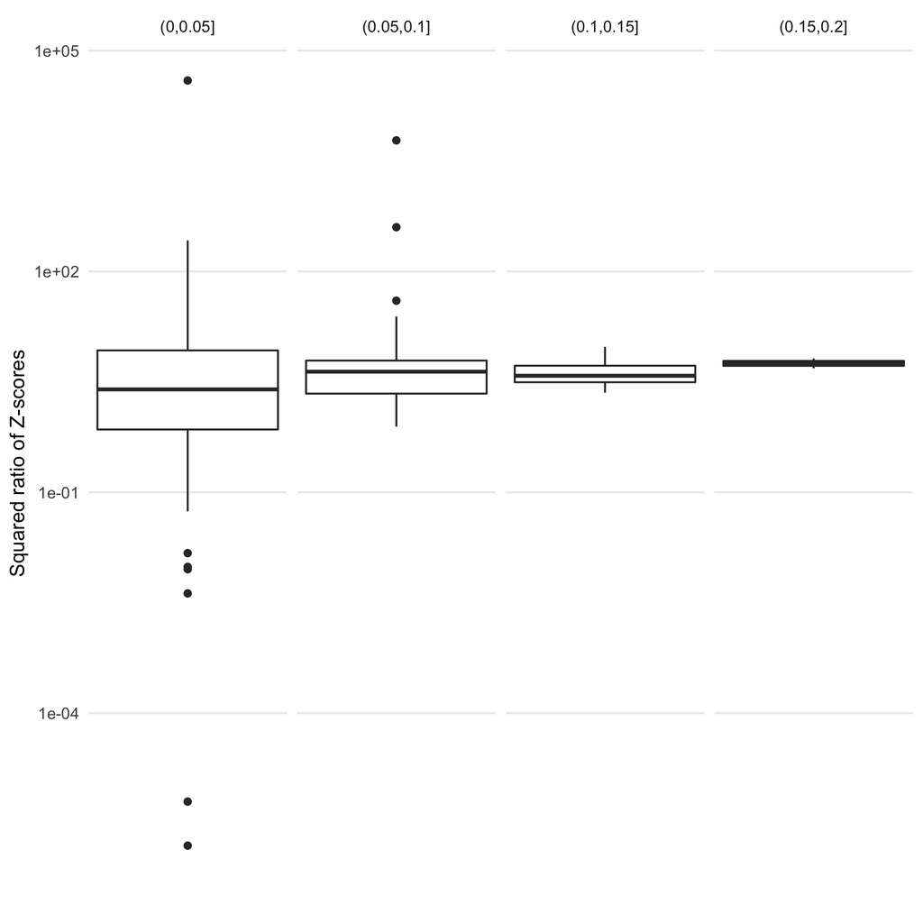

## Figure S2

The effectiveness of LMM using random or top associated markers in capturing the heritability.

The figure extends the top panel of Figure 2 for two types of simulated data with 2.5% and 10% of causal variants.

The top panel reports the estimated heritabilities across the range of the number of selected genetic variants.

The middle panel shows the coverage of causal variants, the proportion of causal variants presented in a set of selected variants.

The bottom panel shows the proportion of causal variants, the fraction of selected variants that are causal. For example, this proportion is always 1 when only causal variants are selection (middle column).

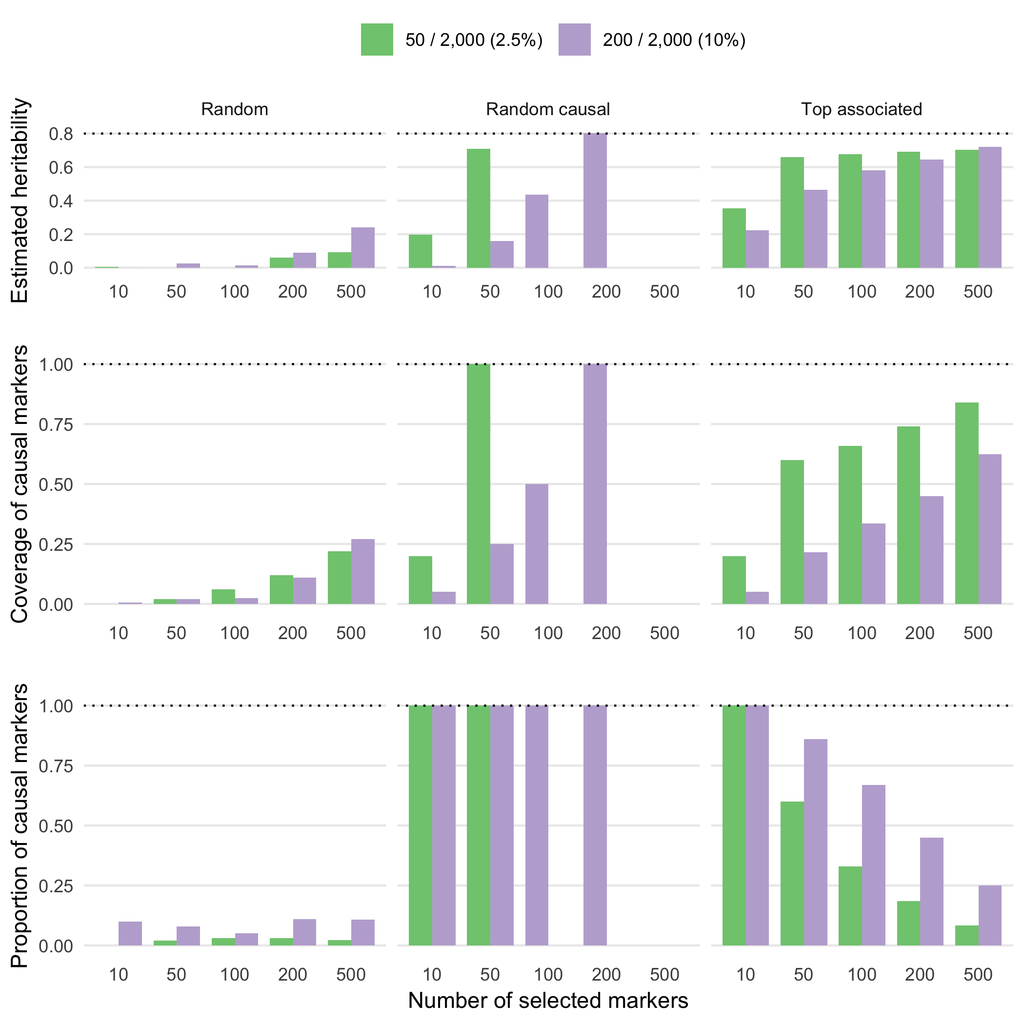

## Figure S3

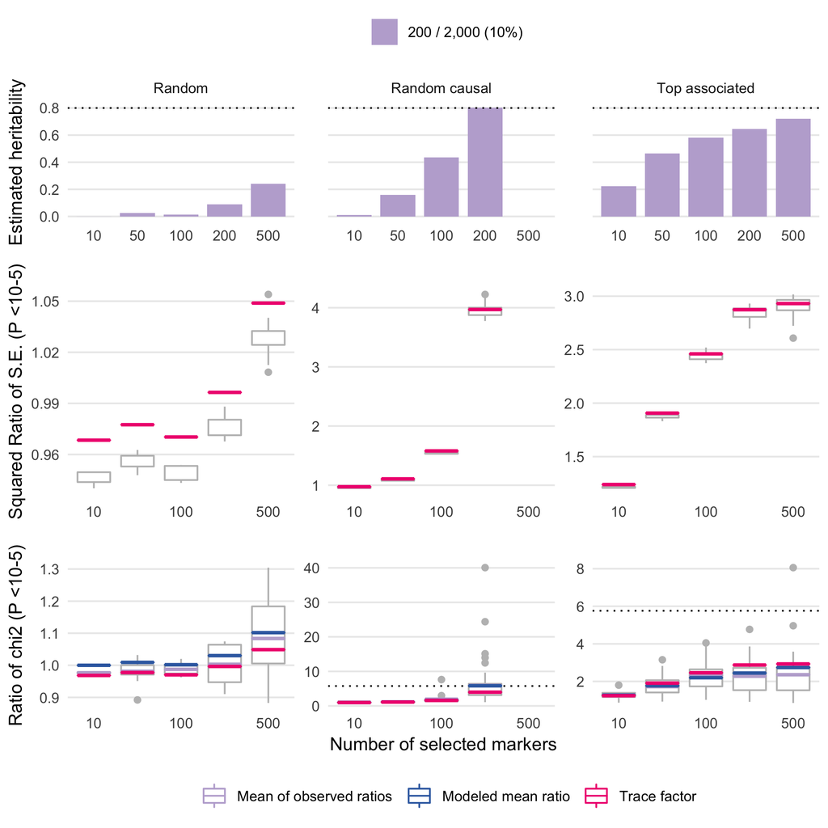

# 3 TODO

`(1)` If we assume that a low-rank GRM of 1,000 SNPs well approximates the genome-wide GRM in the LMM analysis, can we use our low-rank effective sample size multiplier to predict the genome-wide one? The genome-wide heritability for Height and BMI on 337K unrelated British are 0.579 and 0.308 and the genome-wide effective sample size multipliers are 1.37 and 1.14 (Loh et al. 2018, Supplementary Table 3).

`(2)` We can analytically derive the variance/standard error for our estimator of the effective size multiplier (Lynch and Walsh 1998, Formulas for quadratic forms). Hence, we can plot errors bars on the plots for the red bars.

# Appendix

## Implementation of low-rank linear mixed models

### Base R

Based on the description given in (Young, Wauthier, and Donnelly 2018) (Supplementary Note, Section 5), we implemented the REML algorithm for low-rank mixed models in R: https://github.com/variani/wlm/blob/master/R/lmm1lr.R. The main idea is to replace two costly operations of matrix inversion and determinant calculation by their efficient equivalents:

- https://en.wikipedia.org/wiki/Woodbury_matrix_identity
- https://en.wikipedia.org/wiki/Matrix_determinant_lemma

The additional document “03-sim-gwas.pdf” shows an example GWAS simulation using low-rank mixed models implemented in R.

# References

Loh, Po-Ru, Gleb Kichaev, Steven Gazal, Armin P Schoech, and Alkes L Price. 2018. “Mixed-Model Association for Biobank-Scale Datasets.” *Nature Genetics*. Nature Publishing Group, 1.

Lynch, Michael, and Bruce Walsh. 1998. *Genetics and Analysis of Quantitative Traits*. Vol. 1. Sinauer Sunderland.

Yang, Jian, Noah A Zaitlen, Michael E Goddard, Peter M Visscher, and Alkes L Price. 2014. “Advantages and pitfalls in the application of mixed-model association methods.” *Nature Publishing Group* 46 (2). Nature Publishing Group: 100–106. doi:10.1038/ng.2876.

Young, Alexander I, Fabian L Wauthier, and Peter Donnelly. 2018. “Identifying loci affecting trait variability and detecting interactions in genome-wide association studies.” *Nature Genetics (in Press)* 50 (November). Springer US. doi:10.1038/s41588-018-0225-6.